# Lord’s Paradox

2020/08/20

## Spoiler: It's not a paradox

## Reference

Adapted and simplified from Judea Pearl's more technical and complete [2016 resolution](https://ftp.cs.ucla.edu/pub/stat_ser/r436.pdf) of the paradox.

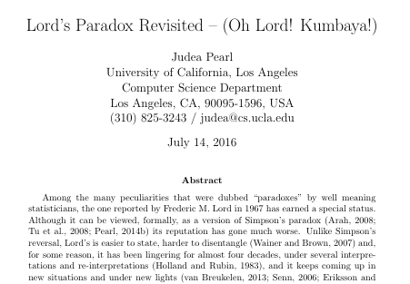

## Lord's Formulation

## The Question

"A large university is interested in investigating the effects on the students of the diet provided in the university dining halls and any sex differences in these effects. Various types of data are gathered. In particular, the weight of each student at the time of his arrival in September and his weight the following June are recorded."" (Lord 1967, p. 304)

- How do students' weights differ between the beginning and end of the year?
- How does sex affect the change in weight?

## Data

Male and female students are weighed at the beginning and end of the school year:

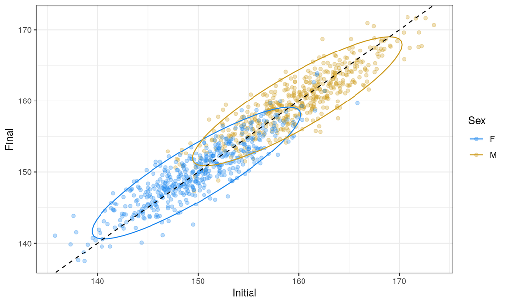

## Analysis

Two stastisticians analyze these data. It was 1967, so the available tools were:

- ANOVA
- ANCOVA

## Statistician 1

The first statistician compares the mean and variance of the initial vs. final weights in each of the two sexes:

- In females, the initial weights have the same mean and variance as the final weights
- Similarly in males, the initial and final weights have the same distribution

Any individual gains or losses cancel each other out, and overall there is negligible change in student weight in either group.

## Statistician 1

### ANOVA

```r
l_a_anov = aov(Weight ~ Timepoint, filter(l_df_long, Sex == 'F'))
Anova(l_a_anov)
```

```
## Anova Table (Type II tests)
##
## Response: Weight
##            Sum Sq  Df F value Pr(>F)
## Timepoint     0.1   1   0.004 0.9496
## Residuals 21128.4 998
```

```r
l_b_anov = aov(Weight ~ Timepoint, filter(l_df_long, Sex == 'M'))
Anova(l_b_anov)
```

```
## Anova Table (Type II tests)
##
## Response: Weight
##            Sum Sq  Df F value Pr(>F)
## Timepoint     3.6   1  0.1728 0.6777
## Residuals 20813.1 998
```

## Statistician 1

### ANOVA

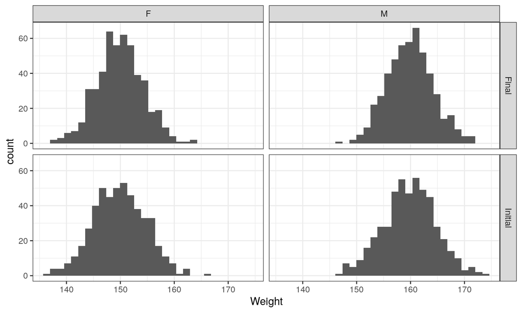

## Statistician 1

### LM 1

We can do an equivalent thing with a linear model:

```r
l_mod1 = lm(Gain ~ Sex, data = l_df)
summary(l_mod1)
```

```
##
## Call:
## lm(formula = Gain ~ Sex, data = l_df)
##
## Residuals:
##     Min      1Q  Median      3Q     Max
## -6.9143 -1.4764 -0.0168  1.5077  6.5446
##
## Coefficients:
##             Estimate Std. Error t value Pr(>|t|)
## (Intercept)  0.01839    0.10195   0.180    0.857
## SexM         0.10168    0.14418   0.705    0.481
##
## Residual standard error: 2.28 on 998 degrees of freedom
## Multiple R-squared:  0.0004981,  Adjusted R-squared:  -0.0005034
## F-statistic: 0.4973 on 1 and 998 DF,  p-value: 0.4808
```

## Statistician 1

### LM 1

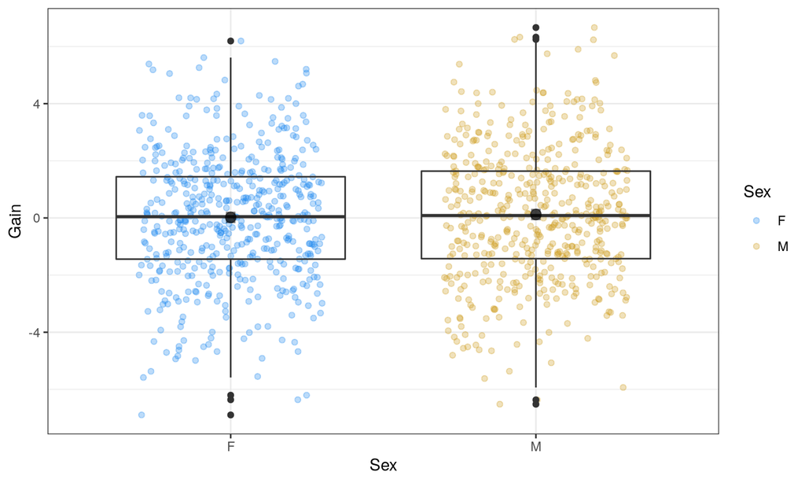

## Statistician 2

### ANCOVA

The second statistician decides to control for the initial weight of the students.

```r
l_ancov = aov(Gain ~ Sex + Initial, data = l_df)
Anova(l_ancov)
```

```
## Anova Table (Type II tests)
##
## Response: Gain
##           Sum Sq  Df F value    Pr(>F)
## Sex        620.6   1  151.52 < 2.2e-16 ***
## Initial   1102.9   1  269.26 < 2.2e-16 ***
## Residuals 4083.9 997
## ---
## Signif. codes:  0 '***' 0.001 '**' 0.01 '*' 0.05 '.' 0.1 ' ' 1
```

## Statistician 2

### LM2

```r
l_mod2 = lm(Gain ~ Sex + Initial, data = l_df)
summary(l_mod2)
```

```
##
## Call:
## lm(formula = Gain ~ Sex + Initial, data = l_df)
##
## Residuals:
##     Min      1Q  Median      3Q     Max
## -6.9913 -1.3603  0.0365  1.3351  6.7667
##
## Coefficients:
##             Estimate Std. Error t value Pr(>|t|)
## (Intercept) 32.50732    1.98201   16.40   <2e-16 ***
## SexM         2.25827    0.18346   12.31   <2e-16 ***
## Initial     -0.21680    0.01321  -16.41   <2e-16 ***
## ---
## Signif. codes:  0 '***' 0.001 '**' 0.01 '*' 0.05 '.' 0.1 ' ' 1
##
## Residual standard error: 2.024 on 997 degrees of freedom
## Multiple R-squared:  0.213,  Adjusted R-squared:  0.2115
## F-statistic: 134.9 on 2 and 997 DF,  p-value: < 2.2e-16
```

## Statistician 2

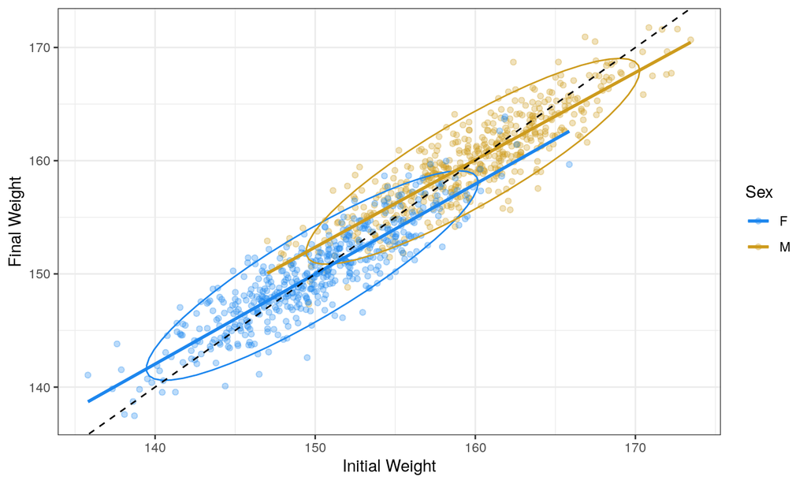

The overall means and distributions may not have changed in either sex, but for any given starting weight, male students gained more than female students.

## What Even

Who is right? How do we decide?

## A Digression: Mediating Variables

## Mediation

[figure not shown]

E.g. does poverty (X) cause cancer (Y)?

## Mediation

[figure not shown]

Maybe poverty (X) increases your exposure to environmental toxins (M), and it's that exposure that causes cancer (Y). I.e. Environmental toxins *mediate* the effect of poverty on cancer risk.

## Mediation

[figure not shown]

And maybe there are other ways in which poverty affects cancer risk that have nothing to do with environmental toxins.

## Mediation

We can think of the effect of X on Y in two ways:

[figure not shown]

- **Total effect:**
  - \(TE = (b + ac) - a\)
  - \(TE = b - a(1 - c)\)

## Mediation

We can think of the effect of X on Y in two ways:

[figure not shown]

- **Total effect:**
  - \(TE = (b + ac) - a\)
  - \(TE = b - a(1 - c)\)
- **Direct effect:**
  - \(DE = b\)

## Construct a mediated dataset

**NOT** Lord's data

[figure not shown]

## Construct a mediated dataset

[figure not shown]

```r
# Start with 1000 students
f_0 = rnorm(500, 150, 5)
m_0 = rnorm(500, 160, 5)
```

- \(a\): initial weight is higher in males than in females

## Construct a mediated dataset

[figure not shown]

```r
# Start with 1000 students
f_0 = rnorm(500, 150, 5)
m_0 = rnorm(500, 160, 5)

g_fun = function(w_0){
    0.2 * w_0 + rnorm(length(w_0))
}
```

- \(a\): initial weight is higher in males than in females
- \(c\): weight gain is a linear function of initial weight

## Construct a mediated dataset

[figure not shown]

```r
# Start with 1000 students
m_df = (data.frame(Sex = rep(c('F','M'), each = 500),
                Initial = c(f_0, m_0))
        %>% mutate(Gain = g_fun(Initial),
                   Final = Initial + Gain))
```

- \(a\): initial weight is higher in males than in females
- \(c\): weight gain is a linear function of initial weight
- \(b\): zero. There is no direct effect of sex on weight gain

## Mediated Dataset

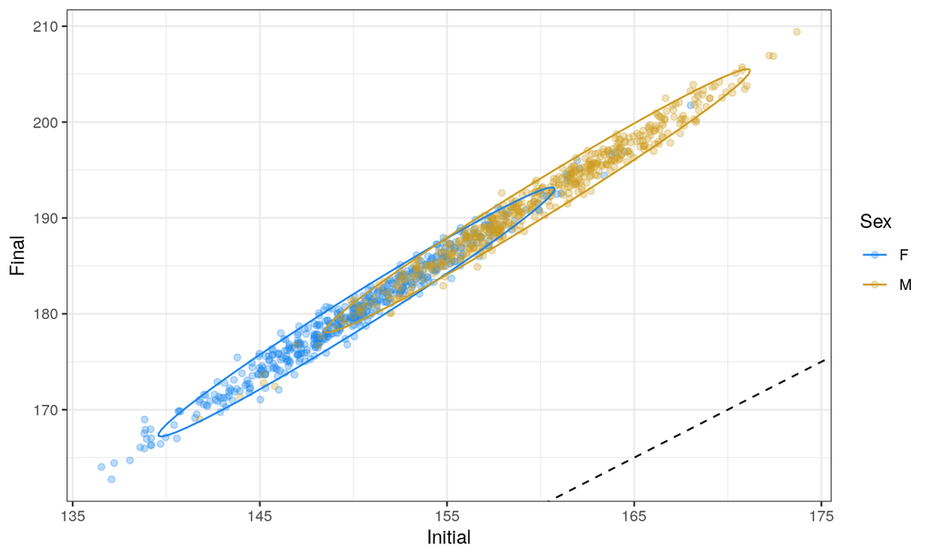

## Bring in Lord's Statisticians

## Statistician 1

Statistician 1 does not control for initial weight; finds clear effect of sex

```r
m_mod1 = lm(Gain ~ Sex, data = m_df)
summary(m_mod1)
```

```
##
## Call:
## lm(formula = Gain ~ Sex, data = m_df)
##
## Residuals:
##     Min      1Q  Median      3Q     Max
## -5.2720 -0.9652 -0.0025  1.0208  3.9888
##
## Coefficients:
##             Estimate Std. Error t value Pr(>|t|)
## (Intercept) 30.03809    0.06428  467.28   <2e-16 ***
## SexM         1.87818    0.09091   20.66   <2e-16 ***
## ---
## Signif. codes:  0 '***' 0.001 '**' 0.01 '*' 0.05 '.' 0.1 ' ' 1
##
## Residual standard error: 1.437 on 998 degrees of freedom
## Multiple R-squared:  0.2996, Adjusted R-squared:  0.2989
## F-statistic: 426.8 on 1 and 998 DF,  p-value: < 2.2e-16
```

## Statistician 1

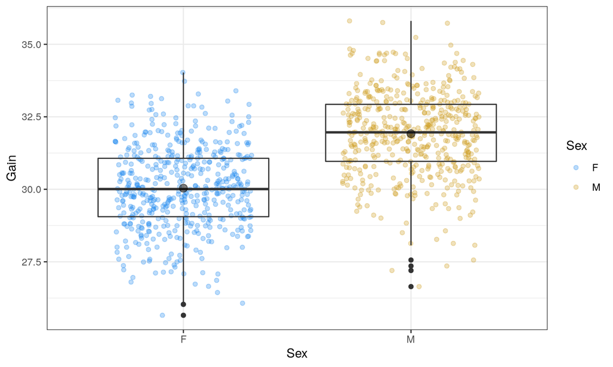

The sexes differ in how much weight they gain. We can see it right there in the data.

## Statistician 1

[figure not shown]

- Statistician 1 is looking at the **total effect** of sex: \(TE = b - a(1 - c)\)
- \(b\) was zero, but \(a\) and \(c\) were not

## Statistician 2

Controls for initial weight; finds no effect of sex

```r
m_mod2 = lm(Gain ~ Sex + Initial, data = m_df)
summary(m_mod2)
```

```
##
## Call:
## lm(formula = Gain ~ Sex + Initial, data = m_df)
##
## Residuals:
##      Min       1Q   Median       3Q      Max
## -3.12231 -0.66260  0.00599  0.69154  3.15709
##
## Coefficients:
##              Estimate Std. Error t value Pr(>|t|)
## (Intercept) -0.527663   0.908580  -0.581    0.562
## SexM        -0.090706   0.085364  -1.063    0.288
## Initial      0.203564   0.006044  33.681   <2e-16 ***
## ---
## Signif. codes:  0 '***' 0.001 '**' 0.01 '*' 0.05 '.' 0.1 ' ' 1
##
## Residual standard error: 0.9836 on 997 degrees of freedom
## Multiple R-squared:  0.6724, Adjusted R-squared:  0.6717
## F-statistic:  1023 on 2 and 997 DF,  p-value: < 2.2e-16
```

## Statistician 2

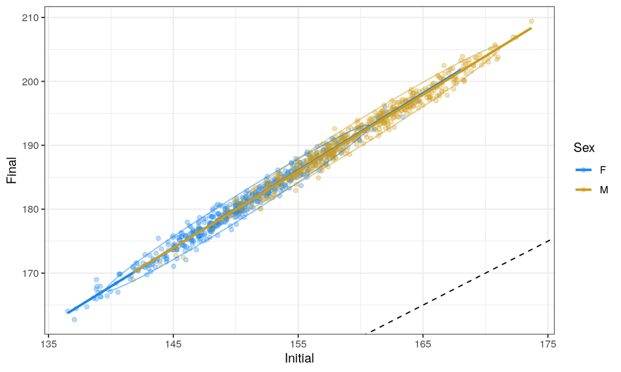

## Statistician 2

[figure not shown]

- Statistician 2 was looking for the **direct effect** of sex: \(DE = b\)
- They correctly found it to be 0

## Context is everything

Who is "correct?"

- What can you measure?
- What story are you trying to tell?
- What is your goal?

## Back to Lord's Paradox

## Tricksiest. Dataset. Ever.

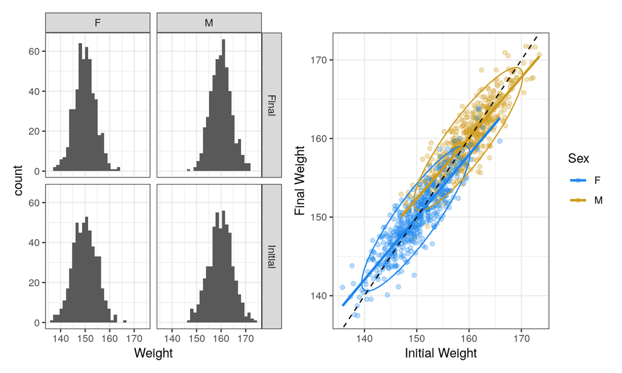

## Tricksiest. Dataset. Ever.

[figure not shown]

- Statistician 2 was looking at \(DE = b\)
  - \(b \ne 0\)
  - Sex is significant

## Tricksiest. Dataset. Ever.

[figure not shown]

- Statistician 2 was looking at \(DE = b\)
  - \(b \ne 0\)
  - Sex is significant
- Statistician 1 was looking at \(TE = b - a(1 - c)\)
  - \(b \ne 0\)
  - \(b\), \(a\), and \(c\) were chosen s.t. \(b = a(1 - c)\)
  - \(TE = b - a(1 - c) = 0\)
- The effect of sex on weight gain is *anti-mediated* by the effect of initial weight.

## Antimediation

Lord plotted **final weight** vs. initial weight

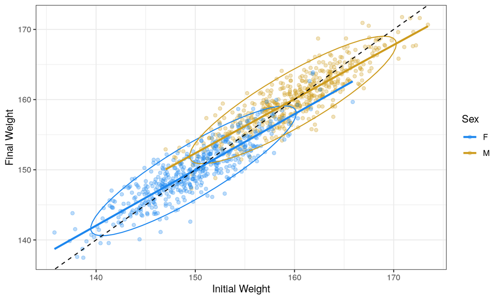

## Antimediation

Look at **gain** vs. initial weight.

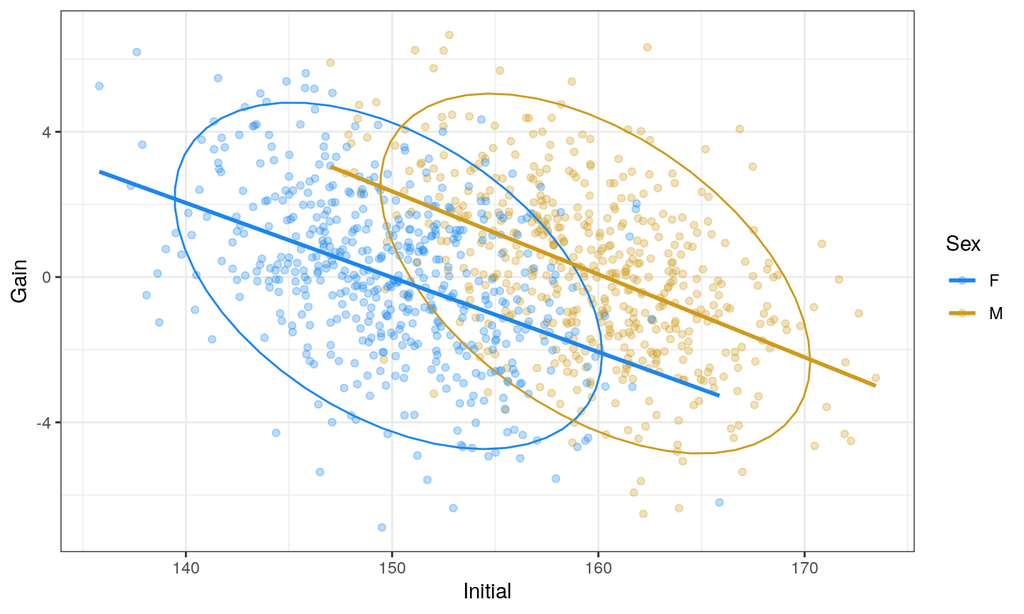

## Antimediation

- Males' initial weight is higher than females'
- Males' weight change intercept is higher than females'
- Initial weight is *negatively* associated with gain

Choose the values correctly, and it all cancels.

## Should I control for baseline values?

## Antimediation

Lord's paradox has nothing to do with baseline values

- Any pair of variable can do this
- E.g. sex & body fat

[figure not shown]

## What Do

## What do we do about this?

Same thing we do every night, Pinky

- Know your system
- Know your question
- Make your decision